# Lasso Regression for Oncology Utilization Management Applications

A report on Lasso Regression for data science projects - Fall 2025

Author

Vijayavel Mohanam, Jennifer Nesbit and Sassou Khabou (Advisor: Dr. Cohen)

Published

December 3, 2025

Slides:

## Introduction

Least Absolute Shrinkage and Selection Operator (Lasso) and Ridge regression are both regularization techniques used to prevent overfitting and multicollinearity in linear regression models by adding a penalty term to the loss function. The Lasso regression method was first introduced by Tibshirani in 1996 and has become a widely used method in both statistical modeling and machine learning. Lasso regression uses L1 regularization, which adds a penalty proportional to the sum of the absolute values of the coefficients, whereas Ridge uses L2 regularization, which adds a penalty proportional to the sum of the squared coefficients. An additional regularization technique called Elastic Net regression, combines both Lasso and Ridge. This technique is useful when there are many correlated features. The L1 penalty used with Lasso shrinks some coefficients to zero which allows for automated selection while also reducing model complexity. Overall Lasso is able to combine both predictive accuracy with interpretability.

Lasso has demonstrated its versatile and practical uses as it has been applied across diverse applications. In healthcare, Lasso has been used to predict prevalence of child malaria Aheto et al., 2021(Aheto JMK 2021), stroke risk in hypertensive patients Huang & Liu, 2025(Huang and Liu. 2025) and adverse drug reactions in polypharmacy Sommer et al., 2024 (Jakob Sommer 2024). These studies all highlight the ability for Lasso to produce models with fewer predictors while maintaining strong performance and often outperforming Ridge regression models in interpretability. Lasso has also been applied to clinical diagnostics, specifically improving disease classification for glaucoma progression Fujino et al., 2015 (Fujino and Asaoka 2015) and differentiating between hematologic cancers Amaador et al., 2022(Amaador and Kersten 2022). Another medical related paper on gastroenterology (Ali, H et al., 2023)(Ali 2023) also applied Lasso to select key predictors and remove insignificant predictors by setting their coefficients to zero. These applications demonstrate the ability of Lasso to enhance decision making with streamlined models.

Lasso regression has also been proven as an effective methodology in economics and finance. Specifically, in predicting corporate bankruptcy Pereira et al., 2016(Jose Manuel Pereira 2016) and analyzing housing price network connectedness Gabauer et al., 2024(David Gabauer 2024). Lasso has also been used for technology applications such as supporting innovations specifically with sensor selection for wearable respiratory monitoring devices Laufer et al., 2023 (Laufer and Moeller 2023) and improved interpretability with decision tree models Czajkowski et al., 2023 (Czajkowski and Kretowski 2023).

Research has been done to compare the use of Lasso as a methodology to multiple related techniques such as Ridge and Elastic Net. Studies have shown that Ridge regression sometimes outperforms Lasso when predictor variables are highly correlated. However, Lasso tends to be more valuable when only a few predictors are significant and applicable to the problem at hand Vidaurre et al., 2013(Vidaurre and Larrañaga 2013). Overall, Lasso shows a consistent advantage with its ability to produce sparse, interpretable and efficient models making it an excellent tool for both modeling and research.

A principal advantage of Lasso (Least Absolute Shrinkage and Selection Operator) regression is its capacity for feature shrinkage and selection. As established in the seminal works by “Introduction to the Lasso” (Gauraha, N, 2018)(Gauraha 2018), selection of most relevant variables from a large set of clinical and pathological data while shrinking less important ones to zero(Li, Y., Bai. 2023)(Li 2023) and “Regression Shrinkage and Selection Via the Lasso” (Robert Tibshirani. 1996)(Tibshirani 1996). They also compare lasso regression to both ridge regression and subset selection. Unlike in ridge regression, where all parameters can only asymptotically approach zero, lasso regression allows some parameters to reach zero. These techniques are applied in Machine Learning for feature selection techniques in predictive modeling (R. Muthukrishnan and R. Rohini. 2016)(Muthukrishnan and Rohini 2016) .On the same lines, we can see how to handle zero inflated predictors(Mariella Gregorich et al., 2025)(Mariella Gregorich 2025) handled by Lasso.

After considering the multiple impactful applications of Lasso regression, this study will apply Lasso to a real-world healthcare problem using the Surveillance, Epidemiology and End Results (SEER) database. Specifically, we aim to develop predictive models that will estimate the likelihood of various cancer treatments such as chemotherapy, radiation therapy or surgery based on patient demographics and clinical characteristics. We will leverage the ability of Lasso to select the most influential factors driving treatment decisions while automatically excluding less informative predictors. The ultimate goal of this application is to support utilization management processes by streamlining treatment approval pathways and expediting patient access to appropriate care. Through this study, we aim to demonstrate how Lasso regressive can serve as an effective tool for improving operational efficiency and decision making in oncology care.

## Data Exploration and Visualization

We focused on variables that are clinically relevant and have been shown to influence treatment decisions in breast cancer. These variables have been categorized into three groups: treatment variables, tumor characteristics and patient demographics. Radiation therapy was identified using the variable Radiation recode and chemotherapy from Chemotherapy recode. These variables capture first-course treatments administered after diagnosis. Only first primary malignancies were included to avoid confounding from prior cancer diagnoses and treatments. Patients with missing or unknown key staging information were excluded. Each treatment variable was recoded into a binary outcome with 1 indicating that treatment was received and 0 indicating that treatment was not received or unknown.

The tumor characteristic variables capture the biological and clinical features of each breast cancer case and are significant determinants of prognosis and treatment selection. Tumor size was included as a continuous numeric variable representing the largest tumor dimension in millimeters prior to treatment. Summary stage, based on the Combined Summary Stage with Expanded Regional Codes, categorized disease extent from in situ to distant spread, providing an overall measure of progression. Nodal involvement, recoded from the EOD Regional Nodes variable, was grouped into N0-N3 categories reflecting increasing lymphatic spread. Metastatic indicators for bone, brain, liver, lung and distant lymph nodes were each recoded as binary variables to identify the presence or absence of distant disease. Laterality identified the side of origin (left or right breast), while Clinical Grade summarized tumor differentiation as low, intermediate or high. Hormone receptor and HER2 status (ER, PR, HER2) were each treated as binary variables (positive or negative) and used to characterize molecular subtypes relevant to therapy decisions. Collectively, these variables provide a detailed picture of tumor biology and stage at diagnosis.

Patient demographic variables describe the population characteristics of the sample and help identify disparities in presentation or treatment. Age at diagnosis was grouped into 5-year intervals and treated as an ordinal categorical variable. Sex was coded as a binary variable (male/female). Race, Hispanic origin and the combined race/ethnicity recode were included as categorical variables to capture sociodemographic diversity and potential disparities. Marital status as diagnosis was collapsed into partnered versus unpartnered categories to assess social support influences. The type of reporting source identified the institution or data source contributing to each case and the year of diagnosis (2018-2022) was treated as a categorical variable. Overall, these demographic factors contextualize differences in clinical presentation and treatment patterns across the study population.

Table 1

*Treatment Variables*

| Variable Name | Description | Seer Codes (2018-2022) | Recoding for modeling |
| --- | --- | --- | --- |
| Radiation recode | Radiation of the primary site | Beam radiation Radioactive implants (includes brachytherapy) (1988+) Refused (1988+) Combination of beam with implants or isotopes None/Unknown | Binary: 1 = any radiation [Beam radiation Radioactive implants (includes brachytherapy) (1988+), Refused (1988+), Combination of beam with implants or isotopes] 0 = no radiation or unknown [None/Unkno… |
| Chemotherapy recode | The chemotherapy given as a part of the first course of treatment or the reason that chemotherapy was not given. | Yes = patient had chemotherapy No/Unknown = no evidence of chemotherapy was found in the medical records examined | Binary: 1 = any chemotherapy[Yes] 0 = no chemotherapy [No/Unknown] |
| Sequence number | Describes the number and sequence of all reportable malignant, in situ, benign, and borderline primary tumors that occur over the lifetime of a patient. | One primary only 1st of 2 or more primaries 2nd of 2 or more primaries etc. | Filter data to only include “One primary only” and “1st of 2 or more primaries” |

Table 2

*Treatment Characteristics*

| Variable Name | Description | Seer Codes (2018-2022) | Recoding for modeling |
| --- | --- | --- | --- |
| Tumor Size Summary (2016+) | Size of a solid primary tumor before any treatment | 000 = No mass/tumor found 001 = 1 mm or described as less than 1 mm (0.1 cm or less than 0.1 cm) 002-988 = Exact size in millimeters (2 mm to 988 mm) (0.2 to 98.8 cm) 989 = 989 millimeters or larger (… | Continuous numeric |
| Combined Summary Stage with Expanded Regional Codes (2004+) | Cancer staging system that categorizes the extent of cancer spread from its point of origin using a combination of clinical and pathological data. | In situ Localized only Regional by direct extension only Regional lymph nodes involved only Regional by both direct extension and lymph node involvement Distant site(s)/node(s) involved Unknown/unstag… | Categorical: In situ Localized only Regional by direct extension only Regional lymph nodes involved only Regional by both direct extension and lymph node involvement Distant site(s)/node(s) involved U… |
| EOD Regional Nodes Recode (2018+) | Records the farthest regional lymph node chain involved by a tumor | 000 = No clinical regional lymph node involvement 030 = PATHOLOGICAL, ITCs only (malignant cell clusters no larger than 0.2 mm) in regional lymph node(s) 050 = PATHOLOGICAL, Positive molecular finding… | Categorical: N0 = 000, 030, 050, 070 N1 = 100, 150, 200, 250, 300 N2 = 350, 400 N3 = 500, 600, 700 NX = 800, 999 |
| SEER Combined Mets at DX-bone (2010+) | This field identifies whether bone is an involved metastatic site. | No = no bone metastases Yes = yes distant bone metastases N/A Unknown | Binary: No = no bone metastases Yes = yes distant bone metastases *exclude N/A and Unknown |
| SEER Combined Mets at DX-brain (2010+) | This field identifies whether brain is an involved metastatic site. | No = no brain metastases Yes = yes distant brain metastases N/A Unknown | Binary: No = no brain metastases Yes = yes distant brain metastases *exclude N/A and Unknown |
| SEER Combined Mets at DX-liver (2010+) | This field identifies whether liver is an involved metastatic site. | No = no liver metastases Yes = yes distant liver metastases N/A Unknown | Binary: No = no liver metastases Yes = yes distant liver metastases *exclude N/A and Unknown |
| SEER Combined Mets at DX-lung (2010+) | This field identifies whether lung is an involved metastatic site. | No = no lung metastases Yes = yes distant lung metastases N/A Unknown | Binary: No = no lung metastases Yes = yes distant lung metastases *exclude N/A and Unknown |
| Mets at DX-Distant LN | This field identifies whether distant lymph node(s) are an involved metastatic site. | No = no distant lymph node metastases Yes = yes distant lymph node metastases N/A Unknown | Binary: No = no distant lymph node metastases Yes = yes distant lymph node metastases *exclude N/A and Unknown |
| Laterality | Describes the side of a paired organ or side of the body on which the reportable tumor originated. | Right - origin of primary Left - origin of primary Only one side - side unspecified Bilateral, single primary Paired site, but no information concerning laterality | Categorical: Right - origin of primary Left - origin of primary Bilateral, single primary *exclude “Only one side - side unspecified Bilateral, single primary” and “Paired site, but no information con… |
| Grade Clinical (2018+) | Records the grade of a solid primary tumor before any treatment | 1 = G1: Low combined histologic grade (favorable), SBR score of 3–5 points 2 = G2: Intermediate combined histologic grade (moderately favorable); SBR score of 6–7 points 3 = G3: High combined histolog… | Categorical: Low = 1, A, L Intermediate = 2, B, M High = 3, C, H, D *exclude N/A (8) and unknown (9) |
| ER Status Recode Breast Cancer (1990+) | Results of the estrogen receptor (ER) assay | Negative Positive Borderline/Unknown Recode not available | Binary: Negative Positive *exclude Borderline/Unknown, Recode not available |
| PR Status Recode Breast Cancer (1990+) | Results from the progesterone receptor (PR) assay | Negative Positive Borderline/Unknown Recode not available | Binary: Negative Positive *exclude Borderline/Unknown, Recode not available |
| HER2 Overall Summary Recode (2018+) | Summary of results from HER2 testing | HER2 negative; equivocal HER2 positive Test ordered, results not in chart Not documented; Cannot be determined; Not assessed or unknown if assessed | Binary: HER2 negative; equivocal HER2 positive *exclude Test ordered, results not in chart, Not documented; Cannot be determined; Not assessed or unknown if assessed |

Table 3

*Patient Demographics*

[output not shown]

## Methods

The basis for LASSO and Ridge regression is Ordinary Least Squares (OLS) regression. The objective of OLS regression is to minimize the sum of the squared residuals, which are the differences between the observed and predicted outcome values. The equation for OLS regression can be expressed as:

$$\begin{equation*} \hat{\beta}_{ols}=\underset{\beta}{\arg\min}\left\{\sum_{i=1}^{N}\left(y_{i}-\beta_{0}-\sum_{j=1}^{p}x_{ij}\beta_{j}\right)^{2}\right\} \tag{1} \end{equation*}$$

Where *N* is our number of observations, *p* is our number of parameters, *y<sub>i</sub>* is an observed outcome variable value, 𝛽<sub>0</sub> is the intercept, *𝑥<sub>ij</sub>* is an observed predictor variable value, and 𝛽<sub>𝑗</sub> is the coefficient for a parameter (Muthukrishnan and Rohini, 2016).

However, while OLS regression has low bias, it is also prone to overfitting and thus high variance. LASSO and Ridge regression remedy this by introducing a shrinkage parameter, denoted as 𝜆. By shrinking the parameters, we introduce some bias but at the benefit of much lower variance.

For LASSO and Ridge regression, respectively, the basic OLS regression equation is modified to:

$$\begin{equation*} \hat{\beta}^{lasso}=\underset{\beta}{\arg\min}\left\{\frac{1}{2}\sum_{i=1}^{N}\left(y_{i}-\beta_{0}-\sum_{j=1}^{p}x_{ij}\beta_{j}\right)^{2}+\lambda\sum_{j=1}^{p}\left\vert\beta_{j}\right\vert\right\} \tag{2} \end{equation*}$$

$$\begin{equation*} \hat{\beta}^{ridge}=\underset{\beta}{\arg\min}\left\{\sum_{i=1}^{N}\left(y_{i}-\beta_{0}-\sum_{j=1}^{p}x_{ij}\beta_{j}\right)^{2}+\lambda\sum_{j=1}^{p}\beta_{j}^{2}\right\} \tag{3}\end{equation*}$$

where 𝜆 is the shrinkage parameter(Muthukrishnan and Rohini 2016). Clearly, the higher the value of 𝜆, the more the parameters are shrunken towards zero. Simply put, Ridge regression minimizes a combination of the sum of squared residuals and the shrinkage parameter times the squared sum of the parameters (L2-regularization), while LASSO regression minimizes a combination of the sum of squared residuals and the shrinkage parameter times the sum of the absolute values of the parameters (L1-regularization).

Of note, there exists an adaptation of the lasso regression created by Zou in 2006 called the “adaptive lasso”. The “adaptive lasso” penalized each parameter according to the importance, or weight, of its corresponding predictor variable. The adaptive lasso can be written as:

$$\begin{equation*} \hat{\beta}^{adaptive lasso}=\underset{\beta}{\arg\min}\left\{\frac{1}{2}\sum_{i=1}^{N}\left(y_{i}-\beta_{0}-\sum_{j=1}^{p}x_{ij}\beta_{j}\right)^{2}+\lambda\sum_{j=1}^{p} w_{j}\left\vert\beta_{j}\right\vert\right\}\tag{4}\end{equation*}$$

where 𝑤<sub>𝑗</sub> is the weight assigned to a certain parameter(Vidaurre and Larrañaga 2013).

LASSO regression was selected to identify key predictors of treatment receipt (radiation and/or chemotherapy) among breast cancer patients. LASSO applies an L1 regularization penalty to the regression coefficients, shrinking less influential predictors toward zero while retaining the most relevant variables. This method is particularly appropriate for the SEER dataset which includes numerous clinical and demographic variables. Separate lasso models will be constructed for radiation and chemotherapy as binary outcome variables (1 = treatment received, 0 = not received/unknown). Predictors include the tumor characteristics and patient demographic variables.

## Analysis and Results

This analysis consisted of two Lasso regression models that were designed to identify the most influential predictors of first line radiation and chemotherapy use among breast cancer patients in the SEER dataset. These models were constructed with the goal of informing utilization management (UM) processes where expedited, evidence based approvals of treatments are essential for minimizing unnecessary delays in patient care. To prepare the data for modeling, all categorical variables were converted into a full model matrix using model.matrix( ) to ensure that the data was compatible with the regularization algorithm. The response variable (tv_radiation or tv_chemotherapy) was extracted as a separate numeric vector.

The predictors were fitted to a wide range of λ penalty values using the glmnet package with alpha = 1. Ten-fold cross validation was used (cv.glmnet()) to identify the λ that minimized prediction error. By choosing the λ that produced the best performing model, the analysis ensured that the predictive patterns were both statistically sound and clinically meaningful and generalizable. Generalizability is an important requirement for UM applications that rely on models that remain stable across diverse patient populations.

```r
library(data.table)
library(ISLR2)
library(glmnet)
library(dplyr)
library(tidyr)
```

### Radiation prediction data

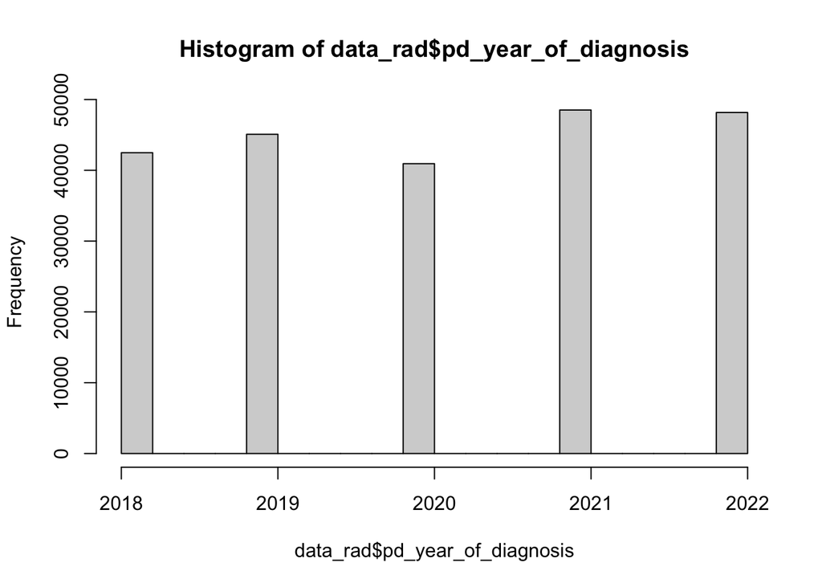

```r
#datar <- fread("/Users/vmohanam/Downloads/data/Selected_var_formated.csv")

data_rad = na.omit(fread("/Users/vmohanam/Downloads/data/Selected_var_formated_rad.csv"))
#str(data)
x = model.matrix(tv_radiation~., data_rad)[,-1]
y = data_rad %>%
  select(tv_radiation) %>%
  unlist() %>%
  as.numeric()
#hist(data$tv_radiation)
hist(data_rad$pd_year_of_diagnosis)
```

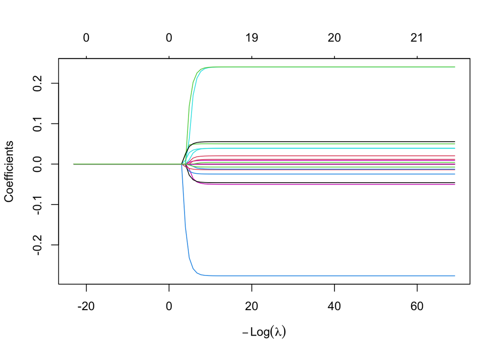

```r
grid = 10^seq(-30, 10, length = 100)
lasso_fit = glmnet(x, y, alpha = 1, lambda = grid, standardize = TRUE, nfolds = 10)

plot(lasso_fit)
```

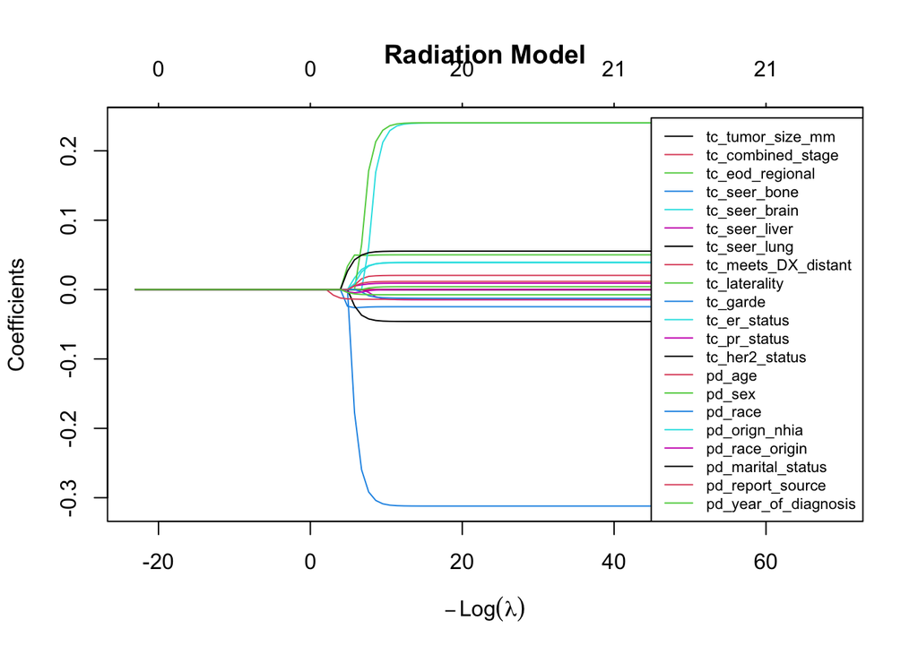

```r
#find the best CV lambda
lambda_cv <- lasso_fit$lambda.min

# Best cross-validated lambda

# Fit final model, get its sum of squared residuals and multiple R-squared
model_cv <- glmnet(x, y, alpha = 1, lambda = lambda_cv, standardize = TRUE)
y_hat_cv <- predict(model_cv, x)
ssr_cv <- t(y - y_hat_cv) %*% (y - y_hat_cv)
rsq_lasso_cv <- cor(y, y_hat_cv)^2
#rsq_lasso_cv

# See how increasing lambda shrinks the coefficients --------------------------
# Each line shows coefficients for one variables, for different lambdas.
# The higher the lambda, the more the coefficients are shrinked towards zero.
res <- glmnet(x, y, alpha = 1, lambda = grid, standardize = FALSE)
plot(res, xvar = "lambda")
legend("bottomright", lwd = 1, col = 1:6, legend = colnames(x), cex = .7)
title ("Radiation Model")
```

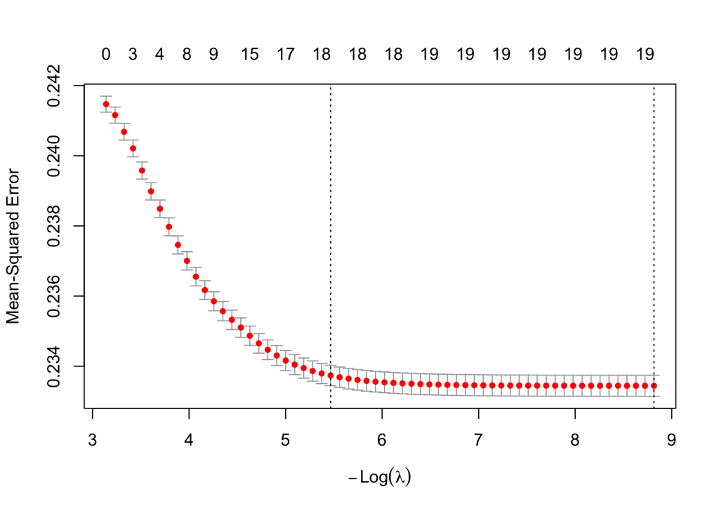

```r
set.seed(1)
cv.out = cv.glmnet(x, y, alpha = 1, standardize = TRUE, nfolds = 10)
plot(cv.out)
```

```r
bestlam = cv.out$lambda.min
coef(cv.out, s=bestlam)
```

```
22 x 1 sparse Matrix of class "dgCMatrix"
                     s=0.0001483386
(Intercept)           15.2008519949
tc_tumor_size_mm      -0.0003182488
tc_combined_stage      0.0201432702
tc_eod_regional        0.0500679708
tc_seer_bone          -0.2750098402
tc_seer_brain          0.2366849895
tc_seer_liver         -0.0500435200
tc_seer_lung           .
tc_meets_DX_distant    .
tc_laterality          0.0038555541
tc_garde              -0.0245583187
tc_er_status           0.0385390793
tc_pr_status           0.0091225213
tc_her2_status        -0.0455950373
pd_age                -0.0139552111
pd_sex                 0.2385434118
pd_race               -0.0122154849
pd_orign_nhia          0.0387755773
pd_race_origin        -0.0001464841
pd_marital_status      0.0551512596
pd_report_source       0.0114798923
pd_year_of_diagnosis  -0.0073288589
```

### Chemotherapy prediction data

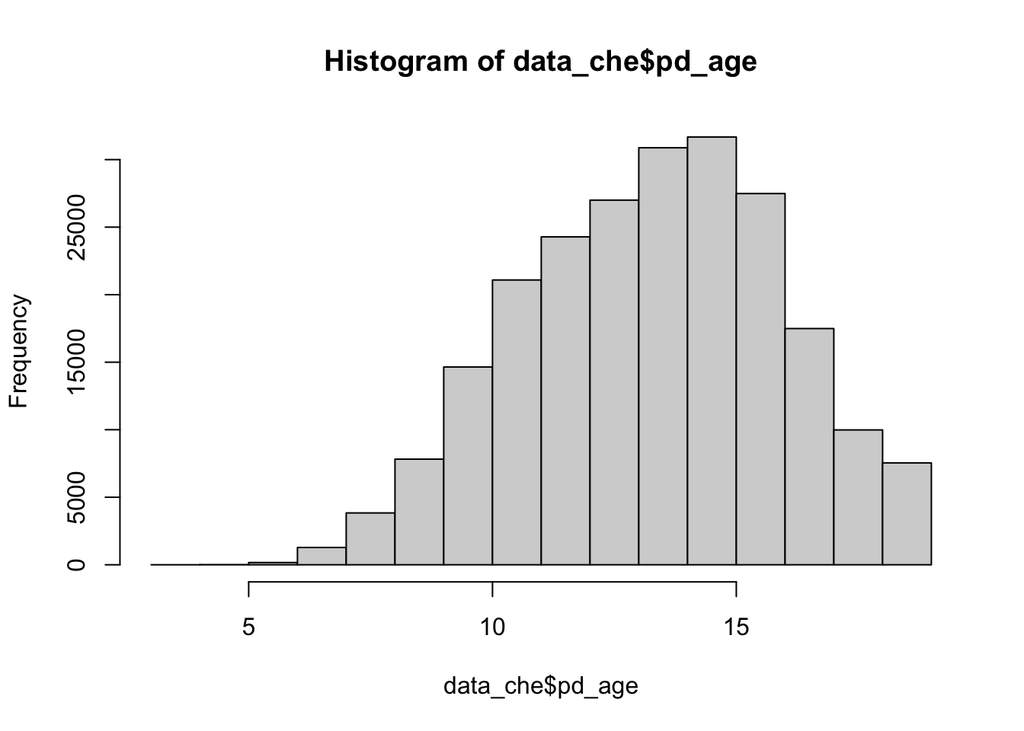

```r
# for chemotheraphy
data_che = na.omit(fread("/Users/vmohanam/Downloads/data/Selected_var_formated_che.csv"))
#str(data)
x2 = model.matrix(tv_chemotherapy~., data_che)[,-1]
y2 = data_che %>%
  select(tv_chemotherapy) %>%
  unlist() %>%
  as.numeric()
#hist(data$tv_radiation)
hist(data_che$pd_age)
```

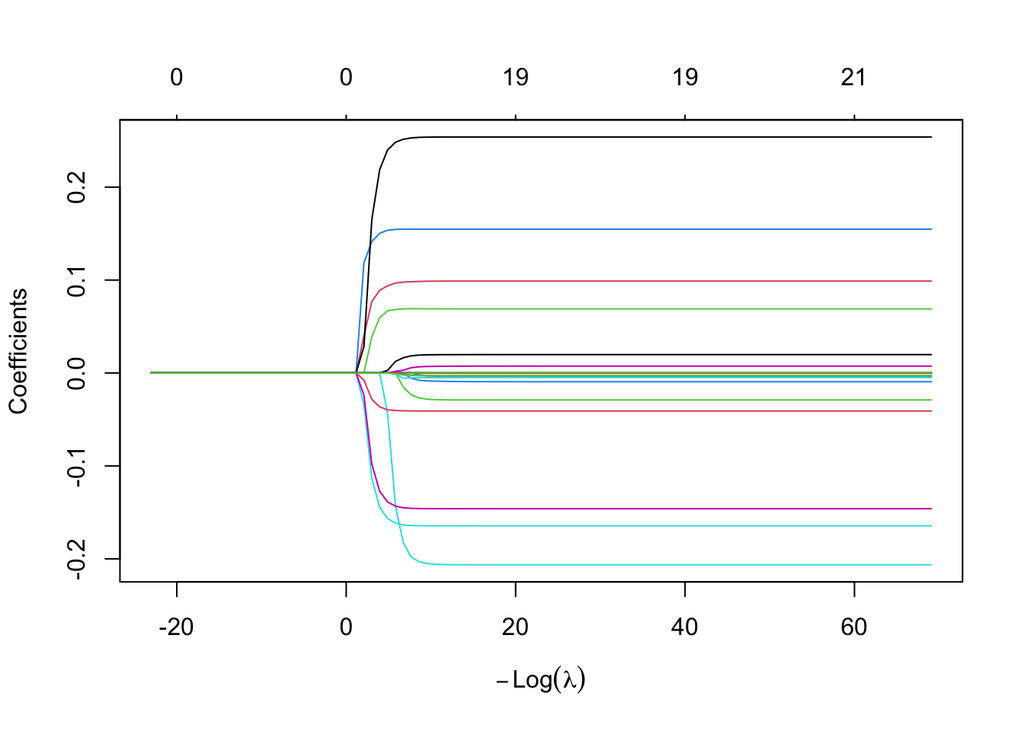

```r
#grid = 10^seq(-30, 10, length = 100)
lasso_fit2 = glmnet(x2, y2, alpha = 1, lambda = grid, standardize = TRUE, nfolds = 10)

plot(lasso_fit2)
```

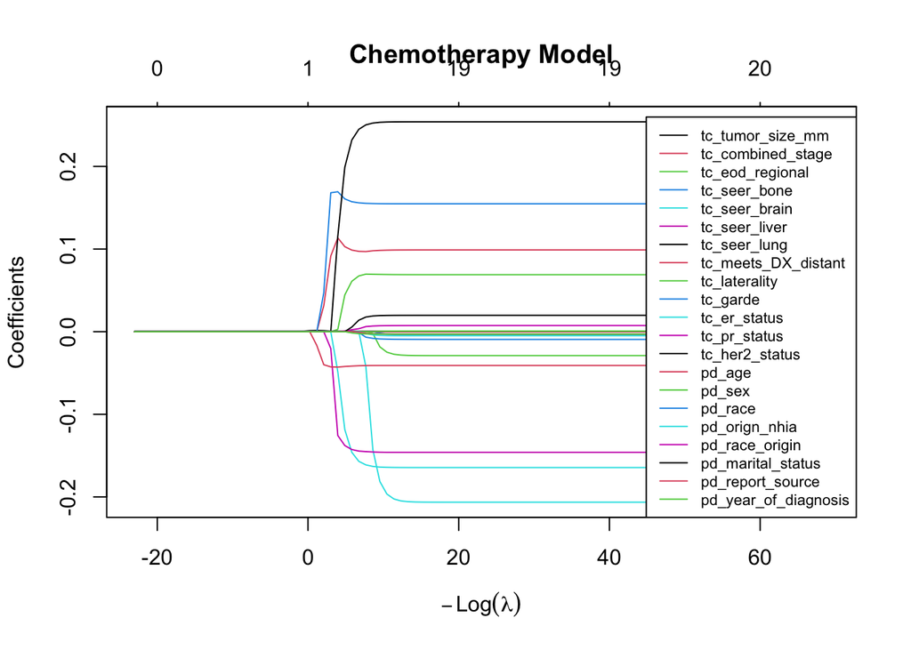

```r
#find the best CV lambda
lambda_cv2 <- lasso_fit2$lambda.min

# Best cross-validated lambda

# Fit final model, get its sum of squared residuals and multiple R-squared
model_cv2 <- glmnet(x2, y2, alpha = 1, lambda = lambda_cv2, standardize = TRUE)
y_hat_cv2 <- predict(model_cv2, x2)
ssr_cv2 <- t(y2 - y_hat_cv2) %*% (y2 - y_hat_cv2)
rsq_lasso_cv2 <- cor(y2, y_hat_cv2)^2
#rsq_lasso_cv

# See how increasing lambda shrinks the coefficients --------------------------
# Each line shows coefficients for one variables, for different lambdas.
# The higher the lambda, the more the coefficients are shrinked towards zero.
res2 <- glmnet(x2, y2, alpha = 1, lambda = grid, standardize = FALSE)
plot(res2, xvar = "lambda")
legend("bottomright", lwd = 1, col = 1:6, legend = colnames(x2), cex = .7)
title ("Chemotherapy Model")
```

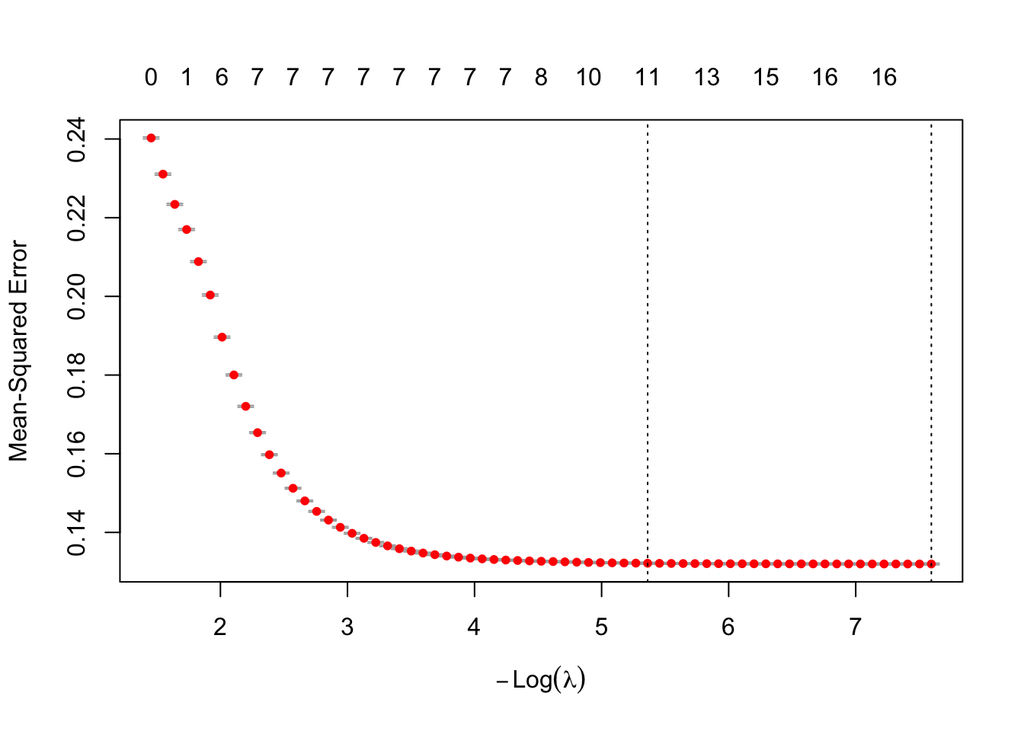

```r
set.seed(1)
cv2.out = cv.glmnet(x2, y2, alpha = 1, standardize = TRUE, nfolds = 10)
plot(cv2.out)
```

```r
bestlam2 = cv2.out$lambda.min
coef(cv2.out, s=bestlam2)
```

```
22 x 1 sparse Matrix of class "dgCMatrix"
                     s=0.000502863
(Intercept)           5.9309324415
tc_tumor_size_mm      0.0002134036
tc_combined_stage     0.0981852499
tc_eod_regional       0.0691773890
tc_seer_bone          .
tc_seer_brain        -0.1972278327
tc_seer_liver         .
tc_seer_lung          .
tc_meets_DX_distant   .
tc_laterality         .
tc_garde              0.1547366121
tc_er_status         -0.1641225556
tc_pr_status         -0.1456254591
tc_her2_status        0.2529096103
pd_age               -0.0408275292
pd_sex               -0.0231049370
pd_race              -0.0053909258
pd_orign_nhia        -0.0052640947
pd_race_origin        0.0054768972
pd_marital_status     0.0183455088
pd_report_source     -0.0022358419
pd_year_of_diagnosis -0.0026783369
```

## Modeling and Results

*Radiation Treatment Model*

Table 4

[output not shown]

*Chemotherapy Treatment Model*

Table 5

[output not shown]

## Implications

The results from both Lasso regression models directly support the problem at hand of creating tools that can improve utilization management workflows and accelerate treatment approvals for breast cancer patients. By clearly identifying clinical factors most strongly associated with providers treatment decisions, the models offer a data driven method to anticipate which treatments are likely appropriate for a given patient’s specific disease characteristics. This type of predictive insight can help UM reviewers move away from manual case-by-case review and toward automated or semi-antimated pathways that approve treatments when the clinical features strongly match established patterns.

## Conclusion

In this study, we applied Lasso regression to real-world health care data using the Surveillance, Epidemiology, and End Results (SEER) database. Specifically, we focused on breast cancer in women during the years 2018-2022. We estimated the likelihood of both radiation therapy and chemotherapy treatment variables based on various tumor characteristic variables and patient demographic variables.

Overall, this study is significant because it suggests that we can look at many patient demographic and clinical tumor variables to evaluate the best treatment options for patients. Every unique patient possesses their own unique demographics and clinical markers. By looking at these many unique variables, we can create a model that finds the optimal patient treatment method for a patient and facilitates the ability of clinicians to create individualized treatment plans. For future studies, we can find another dataset that contains a different set of variables. We can then use Lasso regression, as we did here, to model how these new variables correlate with different treatment options.

## References

Adamo M., & Ruhl, Dickie L. 2018. “SEER Program Coding and Staging Manual 2018.” *National Cancer Institute.*

Aheto JMK, Duah HO, Agbadi P. 2021. “A Predictive Model, and Predictors of Under-Five Child Malaria Prevalence in Ghana.” *Prev Med Rep. 10.1016/j.pmedr.2021.101475*.

Ali, Shahzad, H. 2023. “Application and Impact of Lasso Regression in Gastroenterology.” *A Systematic Review. Indian J Gastroenterol 42, 780–790 (2023)*.

Amaador, Josephine M. I Vos, Karima, and Marie José Kersten. 2022. “Discriminating Between Waldenström Macroglobulinemia and Marginal Zone Lymphoma Using Logistic LASSO Regression.” *Leukemia & Lymphoma 63 (5): 1070–79.*

Czajkowski, Krzysztof Jurczuk, Marcin, and Marek Kretowski. 2023. “Steering the Interpretability of Decision Trees Using Lasso Regression - an Evolutionary Perspective.” *Nformation Sciences 638.*

David Gabauer, Rangan Gupta, Hardik A. Marfatia. 2024. “Estimating u.s. Housing Price Network Connectedness: Evidence from Dynamic Elastic Net, Lasso, and Ridge Vector Autoregressive Models.” *International Review of Economics & Finance Volume 89, Part B, January 2024, Pages 349-362*.

Fujino, Hiroshi Murata, Yuri, and Ryo Asaoka. 2015. “Applying ‘Lasso’ Regression to Predict Future Visual Field Progression in Glaucoma Patients.” *Investigative Opthalmology & Visual Science 56 (4): 2334-.*

Gauraha, N. 2018. “Introduction to the LASSO.” *Reson 23, 439–464 (2018)*.

Huang, Junzhang, and Wencai Liu. 2025. “Comparison of Machine Learning Models for Predicting Stroke Risk in Hypertensive Patients: Lasso Regression Model, Random Forest Model, Boruta Algorithm Model, and Boruta Algorithm Combined with Lasso Regression Model.” *Medicine (Baltimore) 104 (22): E42690.*

Jakob Sommer, Roberto Viviani, Justyna Wozniak. 2024. “Dealing with Adverse Drug Reactions in the Context of Polypharmacy Using Regression Models.” *MC PubMed Central Sci Rep. 2024 Nov 9;14:27355. Doi: 10.1038/S41598-024-78474-4*.

Jose Manuel Pereira, Mario Bastoa, Amelia Ferreira da Silva. 2016. “The Logistic Lasso and Ridge Regression in Predicting Corporate Failure.” *3rd GLOBAL CONFERENCE on BUSINESS, ECONOMICS, MANAGEMENT and TOURISM Volume 39, 2016, Pages 634-641*.

Laufer, Paul D Docherty, Bernhard, and Knut Moeller. 2023. “Ensor Selection for Tidal Volume Determination via Linear Regression—Impact of Lasso Versus Ridge Regression.” *Sensors (Basel, Switzerland) 23 (17): 7407.*

Li, Bai, Y. 2023. “Prognostic Nomograms for Gastric Carcinoma After D2 + Total Gastrectomy to Assist Decision-Making for Postoperative Treatment: Based on Lasso Regression.” *World Journal of Surgical Oncology, 21(1), Article 207*.

Mariella Gregorich, Michael Kammer, Harald Mischak. 2025. “Prediction Modeling with Many Correlated and Zero-Inflated Predictors: Assessing the Nonnegative Garrote Approach.” *Volume 44, Issue 8-910.1002*.

Muthukrishnan, R., and R. Rohini. 2016. “LASSO: A Feature Selection Technique in Predictive Modeling for Machine Learning.” *IEEE International Conference on Advances in Computer Applications (ICACA), Coimbatore, India, 2016, Pp. 18-20*.

Tibshirani, Robert. 1996. “Regression Shrinkage and SelectionVia the Lasso.” *Journal of the Royal Statistical Society: Series B (Methodological), Volume 58, Issue 1, January 1996, Pages 267–288*.

Vidaurre, Concha Bielza, Diego, and Pedro Larrañaga. 2013. “A Survey of L1 Regression.” *International Statistical Review 81 (3): 361–87.*